# New England Forest Composition at the time of European Settlement

Charlotte Uden

5/10/2019

*Back to index*

### Introduction

Humans have been shaping the landscape for thousands of years (Sadori L. 2010). We now know that native american populations in the americas were expansive and their impact on the landscape was significant (Denevan, William M. 1992). Projecting forest composition at the time of settlement may offer some indication of the extent of Native American land use practices. Ultimately, the goal is to use LPJ-GUESS, a dynamic vegetation model, to predict species composition in new england at the time of european settlement.

### Dataset

The model will be run with and without fire disturbance and its output compared with two datasets:

1. Forest Inventory Analysis (FIA): a survey conducted by the united states forest service. This dataset will provide a comparison for current species composition. This dataset will not be included in this analysis.*
2. Witness trees: used by surveyors at the time of european settlement to mark property boundaries. Charlie Cogbill has compiled these records from towns across New England (Cogbill, C.V. 2002). This dataset will be compared with the model output for composition approximately 350 years ago (dates of surveys vary).

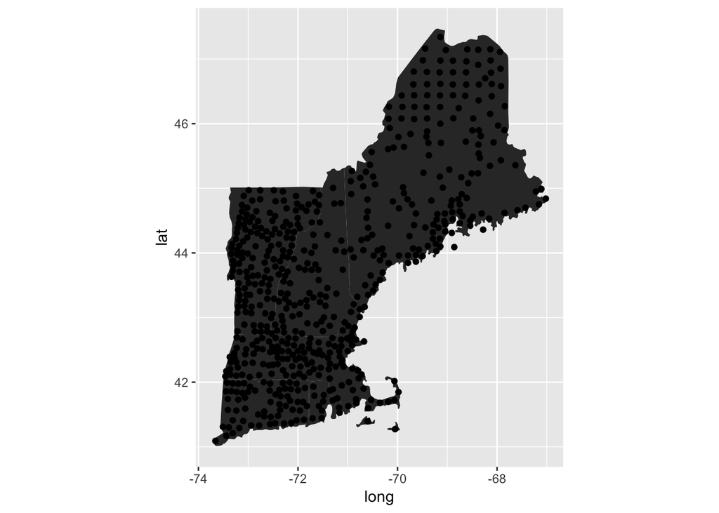

This analysis aims to fit a rarefaction curve to the witness tree dataset. Rarefaction curves, or species accumulation curves, relate species richness to sample size (Fisher, R. A. 1943, Ugland, K. I. 2003). As the number of individuals you sample from a community increases, so does the likelihood of sampling a new species. Because richness is finite, the rarefaction curve eventually flattens, indicating that no additional sampling will yield a new species. Rarefaction curves are often used to estimate species richness in hyperdiverse clades or communities not easily accessible (Colwell, R. K. 1994). In a similar way, access to historic community richness data is limited. This curve could be used to identify sample points (towns) in the witness tree dataset that offer a true representation of forest species composition at the time of settlement. For example, data points that do not meet the minimum sample size needed to yield maximum richness (x value at which the curve flattens) will not be compared with the LPJ-GUESS output.

### Analysis

Richness was calculated for each data point and plotted against sample size. Sample size was log transformed in part to fit a linear model, but also because sample size varies so much -from 46 to 4477 trees.

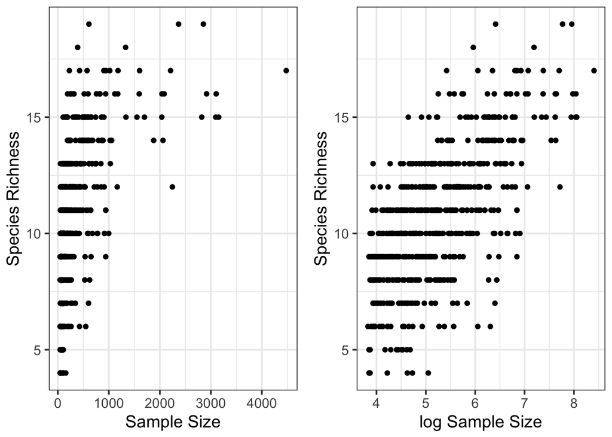

Model 1 fits the data using simple linear regression. Plotting observed against fitted values of richness indicates positive bias for smaller values of richness, and low bias for higher values of richness. Error is evenly dispersed around 0. However, it decreases slightly as both richness and sample size increase. This could be explained by richness being finite: when sample size is large enough, richness will become constant. At this point, more accurate predictions can be made about richness and error will decrease. Residuals are normally distributed.

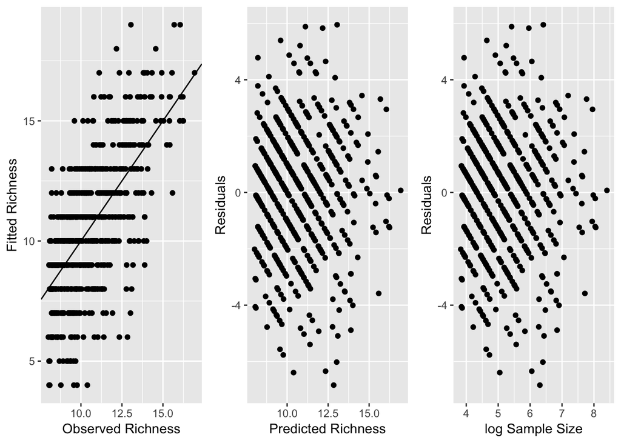

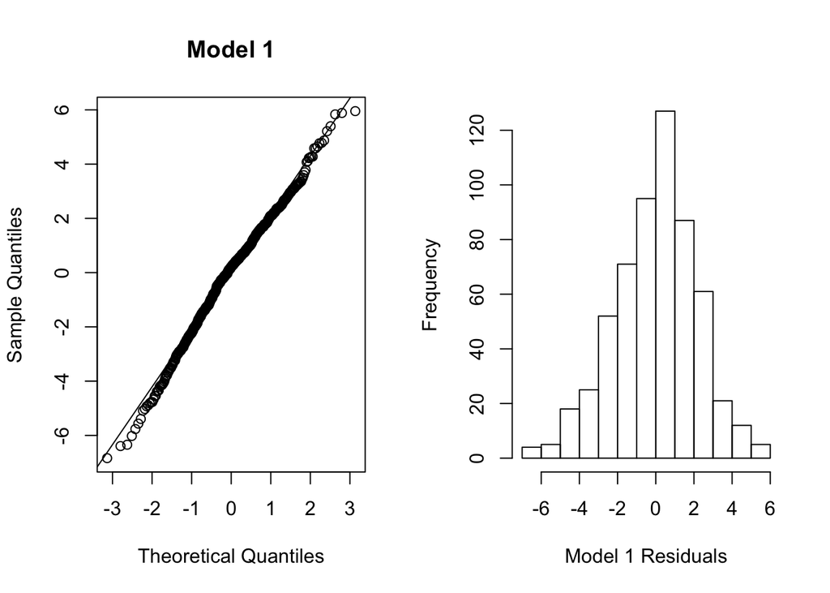

The relationship between species richness and latitude is a global phenomenon seen in a number of taxa, including vascular plants (Hildebrand, H 2004). This latitudinal diversity gradient is maintained at regional levels. Therefore, there is good reason to expect a similar mechanism at play in this dataset. A bubble plot and variogram can be used to check for spatial autocorrelation.

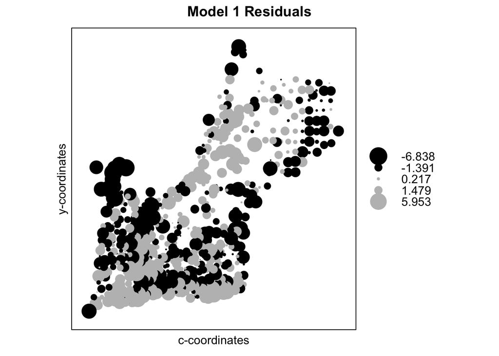

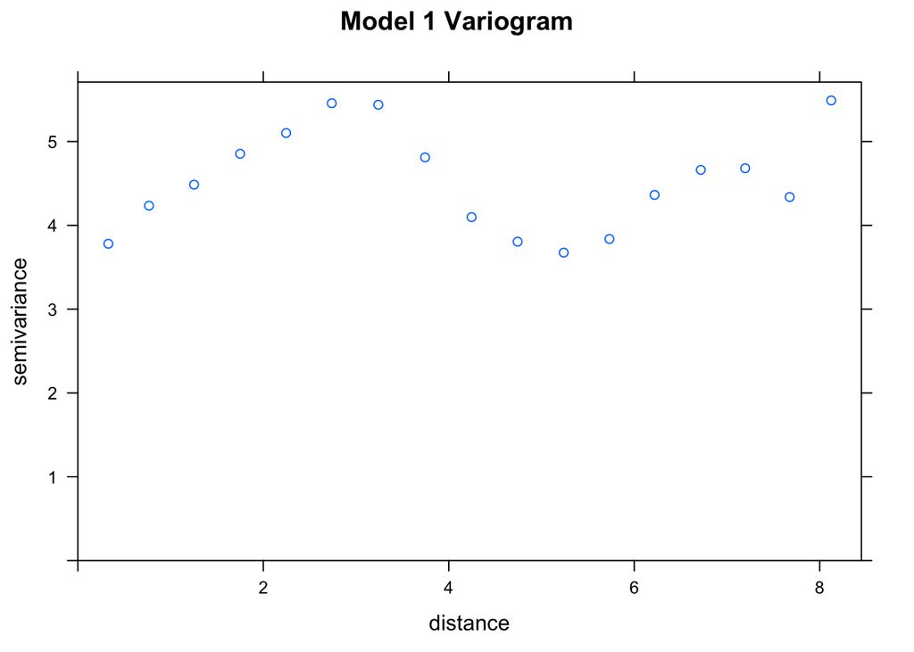

Model 2 fits the data using generalized least squares. The intention here is to us the correlation function to account for spatial autocorrelation in the data. Due to the abnormal shape of the variogram for model 1, choosing a correlation structure is difficult. So, models 2, 3, 4 and 5 are all fitted using generalized least squares, each with a different correlation structure:

- Model 2: exponential correlation (corEXp)
- Model 3: exponential correlation with the range and nugget specified
- Model 4: rational quadratic correlation (corRatio)
- Model 5: gaussian correlation (corGaus)

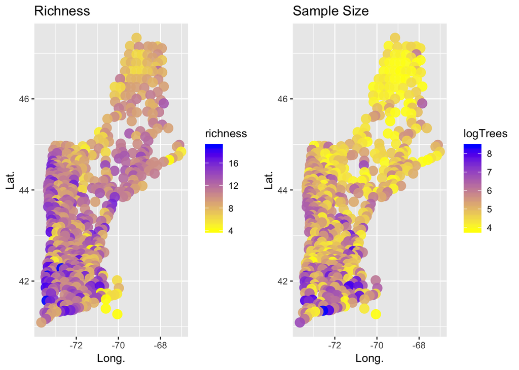

There are no environmental variables in this dataset, so including this parameter is not an immediate option. However, adding state as a factor might deal with correlation between sample size and latitude. Surveying techniques, for example, may differ between states -some favoring the use of witness trees and others preferring stakes or boulders. Further, if richness was in fact lower to the north, forest composition would be more homogenous. Finding one witness tree amongst thousands of identical trees would be far more difficult than in a more diverse stand of trees. So, Model 7 uses the varIdent() function to account for difference in variance for each state. Spatial autocorrelation is still incorporated into the model.

|  | df | AIC |
| --- | --- | --- |
| Mod2 | 5 | 2411.631 |
| Mod7 | 10 | 2387.283 |

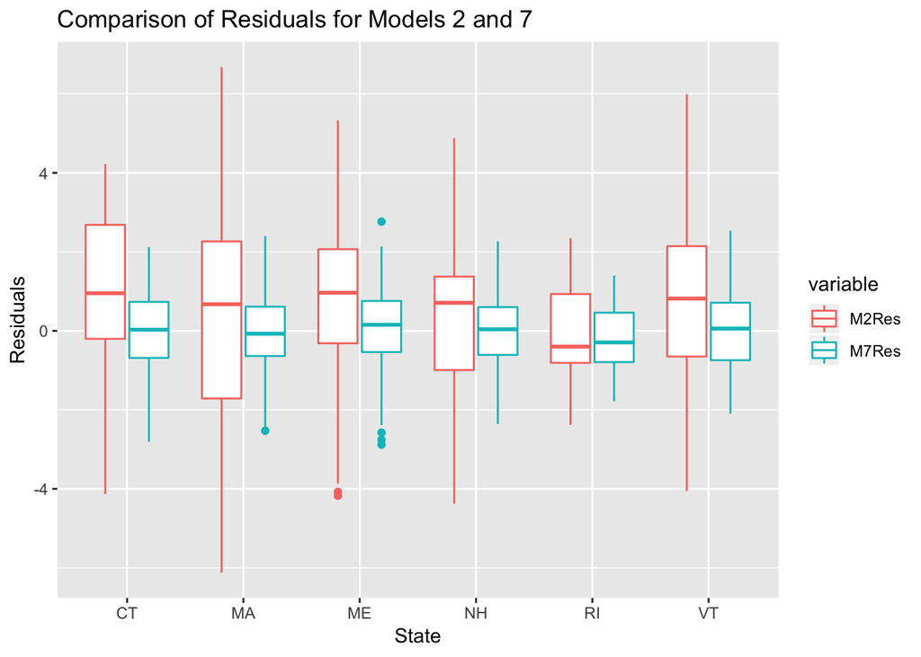

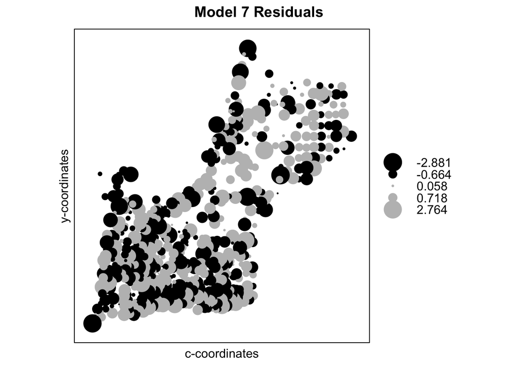

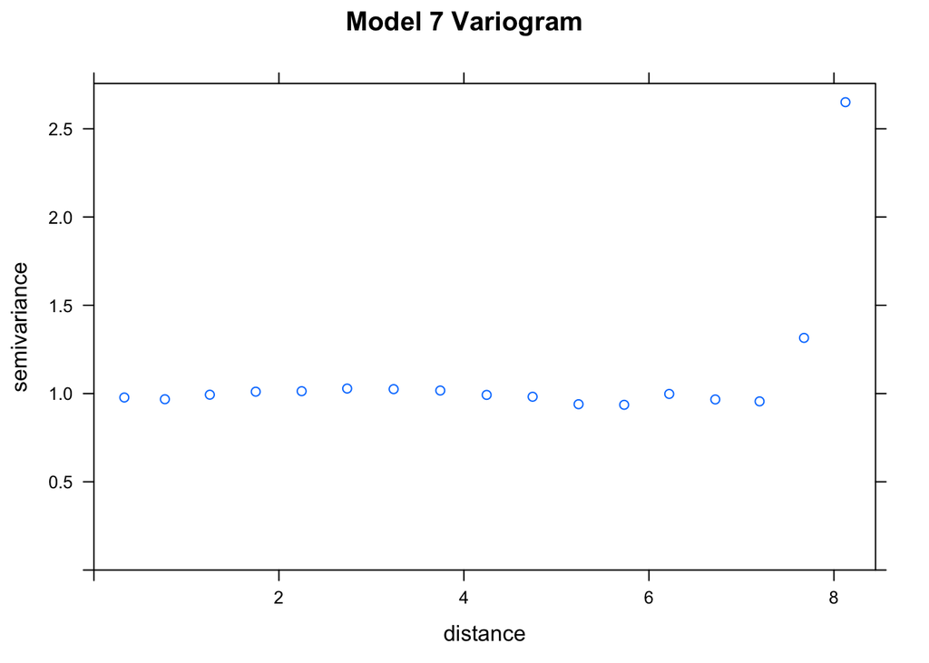

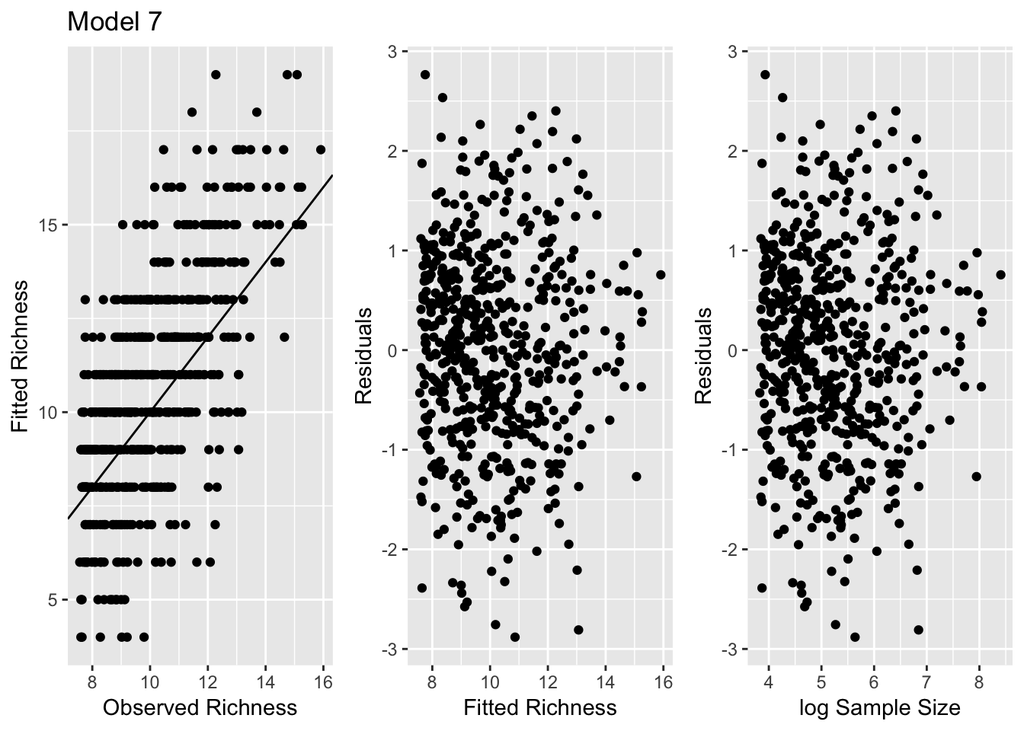

[figure not shown]

### Discussion

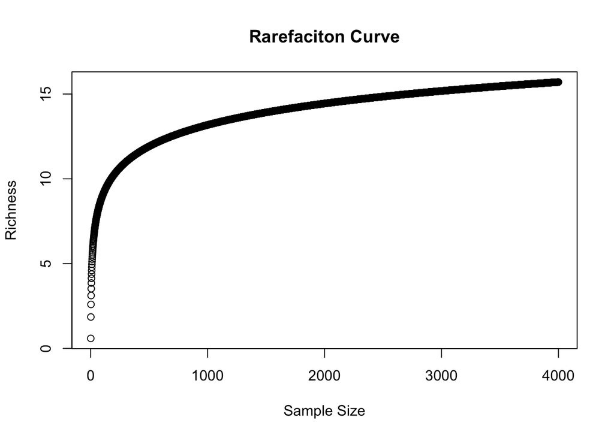

$$richness=0.59 + 1.8223605*log(sampleSize)$$

The slope for log sample size is 1.82. This represents the proportional increase in richness for each increase in sample size. The intercept is at 0.59. However, when sample size is 0, richness should be 0. Furthermore richness is an integer -there is no such thing as a fraction of a species. Despite these flaws in the model, the goal of this analysis can still be achieved. The rarefaction curve provides some insight into which towns provide a large enough sample size to report an accurate measure of richness.

### References

1. Cogbill, C. V., Burk, J., & Motzkin, G. (2002). The forests of presettlement New England, USA: Spatial and compositional patterns based on town proprietor surveys. Journal of Biogeography. https://doi.org/10.1046/j.1365-2699.2002.00757.x
2. Ugland, K. I., Gray, J. S., & Ellingsen, K. E. (2003). The species-accumulation curve and estimation of species richness. Journal of Animal Ecology. https://doi.org/10.1046/j.1365-2656.2003.00748.x
3. Fisher, R. A., Steven-Corbet, A., & Williams, C. B. (1943). The Relation Between the Number of Species and the Number of Individuals in a Random Sample of an Animal. Journal of Animal Ecology.
4. Smith, B., Prentice, I. C., & Sykes, M. T. (2001). Representation of vegetation dynamics in the modelling of terrestrial ecosystems: Comparing two contrasting approaches within European climate space. Global Ecology and Biogeography. https://doi.org/10.1046/j.1466-822X.2001.00256.x
5. Colwell, R. K., & Coddington, J. A. (1994). Estimating terrestrial biodiversity through extrapolation. Philosophical Transactions of the Royal Society of London. Series B, Biological Sciences. https://doi.org/10.1098/rstb.1994.0091
6. Chazdon, R. L., Colwell, R. K., Denslow, J. S., & Guariguata, M. R. (1998). Statistical methods for estimating species richness of woody regeneration in primary and secondary rainforests of northeastern Costa Rica. In Forest biodiversity research, monitoring and modeling: Conceptual background and Old World case studies.
7. Birks, H. J. B., & Line, J. M. (1992). The use of Rarefaction Analysis for Estimating Palynological Richness from Quaternary Pollen-Analytical Data. The Holocene. https://doi.org/10.1177/095968369200200101
8. Denevan, W. M. (1992). The Pristine Myth: The Landscape of the Americas in 1492. Annals of the Association of American Geographers. https://doi.org/10.1111/j.1467-8306.1992.tb01965.x
9. Stevens, G. C. (2002). The Latitudinal Gradient in Geographical Range: How so Many Species Coexist in the Tropics. The American Naturalist. https://doi.org/10.1086/284913
10. Hillebrand, H. (2004). On the Generality of the Latitudinal Diversity Gradient. The American Naturalist. https://doi.org/10.1086/381004
11. Sadori, L., Mercuri, A. M., & Lippi, M. M. (2010). Reconstructing past cultural landscape and human impact using pollen and plant macroremains. Plant Biosystems. https://doi.org/10.1080/11263504.2010.491982